AZUL

Economia, Estatística, Programação

# Ponto Fixo e Equlíbrio Geral

Posted on 2018, Nov 30 by Daniel Coutinho 5 mins read

Faz algum tempo o Pedro escreveu um [post excepcional](https://azul.netlify.com/2018/10/31/banach/) (como de praxe) falando do teorema do ponto fixo (de Banach). Minha única sugestão era um exemplo prático de aplicação do teorema. Este post aplica o teorema em um exemplo de Equilíbrio Geral.

Nosso exemplo vai ser bem simples para ilustrar o ponto: ele não vai ter produção, apenas dotações fixas dos bens - que serão dois. Eu ainda colocarei utilidades Cobb Douglas para termos uma expressão usual da demanda ($\frac{\alpha}{p}m$ e $\frac{1-\alpha}{q}m$, onde $\alpha$ é um parâmetro, $p$ e $q$ são preços e $m$ é a renda).

A parte interessante é que o teorema de ponto fixo usual para Equilíbrio Geral *não* é o de Banach, mas sim o de Kakutani. Eis o enunciado dele:

*Teorema de Ponto Fixo de Kakutani*: seja f uma correspondência semi-continua superior $f: C \rightarrow C$ onde $C$ é um compacto e é convexo. Então, f admite um ponto fixo i.e. $f(a)=a$

(A prova disso é o pesadelo de muitos alunos de pós graduação)

Para aplicar o Teorema, exigimos uma função que mapeie um compacto nele mesmo. Vamos construir essa função. Para isso, defina $z_i$ como o excesso de demanda agregada do bem i, logo $z_i = d(p_i) - w_i$, onde $d()$ é a demanda e $w_i$ é a dotação. Veja que se o preço estiver muito baixo, teremos excesso de demanda e $z_i$ vai ser positivo. E vice versa. Se temos excesso de demanda, precisamos aumentar o preço. Podemos somar ao preço atual uma fração $\delta$ do excesso de demanda para obter novos preços. Isso dá origem a função $\hat{\phi}$:

$$\hat{\phi}(p_i) = p_i + \delta z_i$$

Esta função faz o papel de um leiloeiro que dá um preço e ouve quanto cada consumidor demanda e vê se há bens o suficiente para atender aquela demanda. Esta função mapeia preços em preços, então estamos em um bom caminho. Infelizmente, não há nenhum motivo para afirmar que esse preços estão limitados - uma das condições para ser um compacto. Mas graças a Lei de Walras, podemos normalizar os preços de maneira arbitrária (tudo que importa são preços relativos). A solução é normalizar todos os preços para somarem 1, e isso dá origem a função $\phi$:

A parte interessante é que, em alguns casos, podemos iterar a função $\phi$ e obter um eq partindo de um ponto arbitrário. Vamos primeiro implementar a função demanda e uma função para calcular a renda do sujeito a partir da dotação:

```julia
using Plots
using LinearAlgebra

d1(alfa,p,m) = alfa/p*m

m(p,w) = p*w'
```

Agora a função $\hat{\phi}(p_i)$:

```julia
function phi_hat(p,w,alfa,delta = 0.01)
  m1 = m(p,w)
  z = d1.(alfa,p,m1) - w
  return(p + delta*z)
end
```

phi_hat (generic function with 2 methods)

A função $\phi(p_i)$ simplesmente pega o output da função $\hat{\phi}$ e divide pela soma:

```julia
function phi(p,w,alfa,delta = 0.01)
  q = phi_hat(p,w,alfa,delta)
  q = q ./ sum(q)
  return(q)
end
```

phi (generic function with 2 methods)

Vamos testar se iterar funciona. Vamos trabalhar com o caso em que $\alpha = 0.5$ e que a dotação de ambos os bens é igual a 1. A solução analítica nos diz que os preços tem que ser iguais:

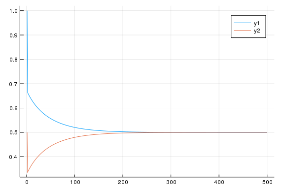

```julia
p = zeros(500,2)
p[1,:] = [1 0.5]

for i=1:499
  p[i+1,:] = phi(p[i,:]',[1 1],[.5 .5])
end

plot(p[:,1])
plot!(p[:,2])
```

Claramente o problema converge para a solução verdadeira. Isso é interessante porque mostra que, para esse caso, um processo de aprendizado que envolve reagir ao último preço leva o mercado a um eventual equilíbrio - uma ideia vinda de Walras que recebe o nome de tâtonnement. Veja que mesmo preços absurdamente distantes funcionam:

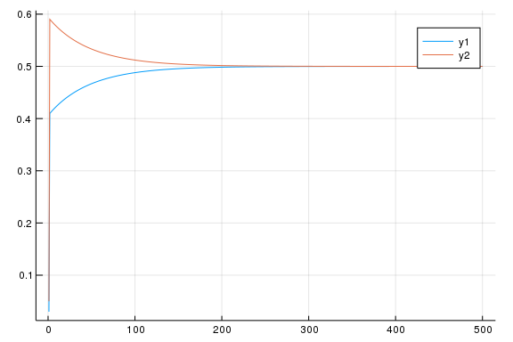

```julia
p = zeros(500,2)
p[1,:] = [0.03 0.05]

for i=1:499
  p[i+1,:] = phi(p[i,:]',[1 1],[.5 .5])
end

plot(p[:,1])
plot!(p[:,2])
```

Veja que o argumento $\delta$ é importante. Colocando $\delta = 1$, o gráfico fica bonito, mas ilustra que não funciona:

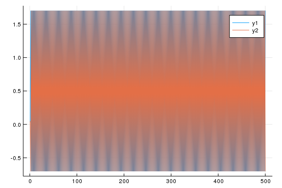

```julia
p = zeros(500,2)
p[1,:] = [0.03 0.05]

for i=1:499
  p[i+1,:] = phi(p[i,:]',[1 1],[.5 .5],1)
end

plot(p[:,1])
plot!(p[:,2])
```

Onde $m=pw_1+qw_2$. Podemos alterar isso para bater com a nossa definição simplesmente definindo $q = 1-p$, e teremos uma função de $\mathbb{R}$ para $\mathbb{R}^2$. O jacobiano (uma generalização da ideia de derivada para funções que tem a imagem em $\mathbb{R^2}$ ou dimensão maior) é:

$$J = \begin{pmatrix} \dfrac{\partial \hat{\phi}_1}{\partial p}
\dfrac{\partial \hat{\phi}_2}{\partial p}
\end{pmatrix} = \begin{pmatrix} 1-\frac{\alpha{}w_2}{p^2}
-1+\frac{(1-\alpha{})w_1}{(1-p)^2}
\end{pmatrix}$$

Veja que para garantir que cada uma dessas funções é uma contração basta garantir que a derivada seja menor (em módulo) que 1. Vamos vizualizar isso para diferentes valores de p, dado os parâmetros do problema:

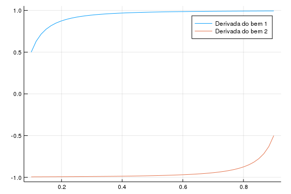

```julia
delt = 0.01

derivada1(p) = 1-delt*0.5/p^2
derivada2(p) = -1+delt*0.5/(1-p)^2

vals = range(0.1,0.9,length=50)

plot(vals,derivada1.(vals),lab = "Derivada do bem 1")
plot!(vals,derivada2.(vals),lab = "Derivada do bem 2")
```

Veja que esse é um caso super específico, e que dependemos do delta escolhido para isso ser de fato uma contração. Observe o valor das derivadas com $\delta=1$:

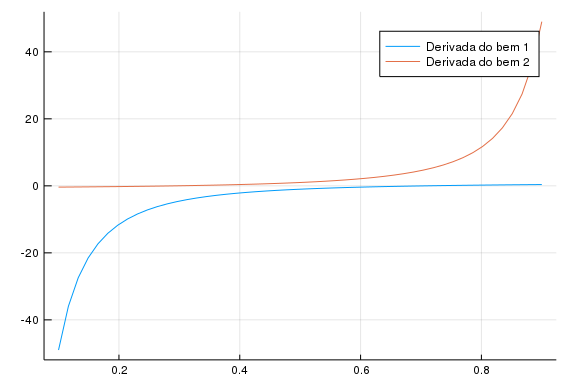

```julia
delt = 1

derivada1(p) = 1-delt*0.5/p^2
derivada2(p) = -1+delt*0.5/(1-p)^2

vals = range(0.1,0.9,length=50)

plot(vals,derivada1.(vals),lab = "Derivada do bem 1")
plot!(vals,derivada2.(vals),lab = "Derivada do bem 2")
```

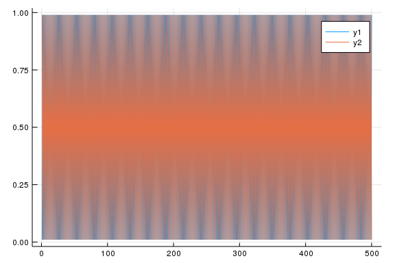

```julia
p = zeros(500,2)
p[1,:] = [0.01 0.99]

for i=1:499
  p[i+1,:] = phi(p[i,:]',[1 1],[.5 .5],1)
end

plot(p[:,1])
plot!(p[:,2])
```

Logo, para alguns valores de $\delta$ e alguns preços iniciais, podemos aplicar o teorema do ponto fixo de Banach ao invés do teorema do ponto fixo de Kakutani.